# Scatterplots / Correlation

Sulalitha Bowala

### Introduction

Regression analysis is a statistical technique used in data analysis to examine relationships between one or more independent variables (predictors) and a dependent variable (response). It is a powerful tool in statistics and data science for understanding how changes in the independent variables can influence the dependent variable. In R, you can perform regression analysis using various functions and packages, with linear regression being one of the most common types.

### Scatterplots

A scatterplot, often called a scatter diagram, is a fundamental data visualization tool used to display the relationship between two or more variables in a dataset. It is a graphical representation that helps us understand how one variable is affected by changes in another. Scatterplots are widely employed in various fields, including statistics, data analysis, data science, and scientific research, to explore and visualize data relationships.

**Key Characteristics of Scatterplots:**

1. **Two Variables:** Scatterplots typically represent two variables on a two-dimensional graph. However, you can create multi-dimensional scatterplots to explore relationships among more than two variables.
2. **Axes:** The horizontal axis (x-axis) represents one variable, while the vertical axis (y-axis) represents another. These variables are often referred to as the independent variable (x) and the dependent variable (y).
3. **Data Points:** Each data point on the plot represents a single observation or case in your dataset. The position of the data point on the graph is determined by the values of the two variables it represents.
4. **Patterns:** By examining the arrangement and patterns of data points on the scatterplot, you can gain insights into the nature of the relationship between the variables. Common patterns include linear, nonlinear, clusters, and outliers.

**Common Uses of Scatterplots:**

1. **Relationship Exploration:** Scatterplots are used to investigate and visualize the relationship between variables. You can quickly determine whether the variables are positively or negatively correlated, linearly related, or exhibit more complex patterns.
2. **Outlier Detection:** Scatterplots help identify data points that deviate significantly from the overall pattern, known as outliers. Outliers can indicate errors, anomalies, or unique cases in the dataset.
3. **Correlation Analysis:** Calculating correlation coefficients, such as Pearson’s correlation coefficient, is often paired with scatterplots to quantify the strength and direction of the relationship between variables.
4. **Model Selection:** Scatterplots assist in choosing appropriate statistical or machine learning models. For example, if the relationship is linear, linear regression may be a suitable choice.
5. **Data Quality Assessment:** Anomalies in the data can be detected through visual inspection. Inconsistent or erroneous data points are more easily identified using scatterplots.
6. **Multivariate Analysis:** When dealing with multiple independent variables, scatterplots can reveal complex interactions and dependencies among variables.

**Interpreting Scatterplots:**

To interpret a scatterplot, consider the distribution of data points, the direction of the relationship (positive, negative, or none), the form of the relationship (linear or nonlinear), and any apparent clusters or trends. Patterns in the scatterplot can guide subsequent data analysis, hypothesis testing, and model building.

In summary, scatterplots are a versatile and powerful tool for visually exploring and understanding relationships in data. They provide a concise, intuitive, and informative way to investigate the dependencies and patterns within datasets, making them a fundamental component of data analysis and visualization.

Let’s consider a scenario where we want to study the relationship between the number of hours spent studying and the exam scores of a group of students.

We have collected number of hours spent on studying for 15 students and their exam scores are recorded.

```r
# Sample data
hours_studied <- c(2, 3, 4, 5, 6, 2, 3, 4, 5, 6, 3, 4, 5, 6, 7)
exam_scores <- c(60, 65, 70, 75, 80, 62, 68, 70, 75, 85, 63, 72, 75, 80, 90)
```

To create a scatterplot in R, we use the `plot` function. In particular, you will use the code `plot(x, y)`, where x and `y are your x- and y-variables.

**Syntax**: plot(x = , y = , main = , xlab = , ylab = , col = , pch = , …)

- x, y: The x and y arguments provide the x and y coordinates for the plot. Any reasonable way of defining the coordinates is acceptable. If supplied separately, they must be of the same length.
- main: A main title for the plot
- xlab: A label for the x axis (defaults to a description of x).
- ylab: A label for the y axis (defaults to a description of x).
- col: The colors for lines and points.
- pch: A vector of plotting characters or symbols.

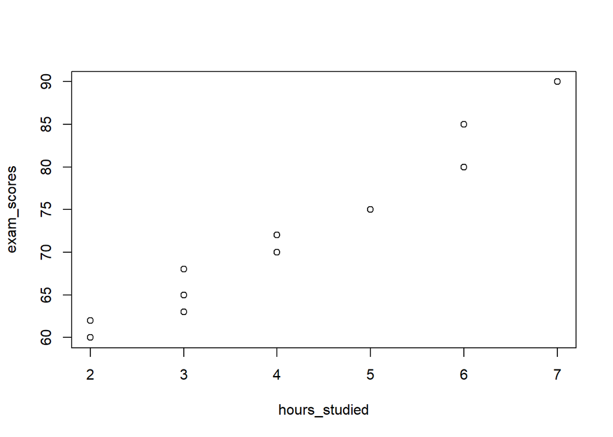

```r
# Create a scatter plot
plot(hours_studied, exam_scores)
```

In this example “hours_studied” represents the number of hours each student spent studying and “exam_scores” represents the corresponding exam scores of those students.

The scatterplot visually illustrates the relationship between the hours spent on studying and the exam scores. We can see that there is a noticeable upwards (positive) linear trend in the data. This indicates that there is, in fact, a substantial positive association between these two variables. However, there is some variability, indicating that someone’s exam score cannot be perfectly predicted from their hours studied.

We can use the `main`, `xlab`, and `ylab` arguments to give meaningful titles to the graph, the x-axis, and the y-axis.

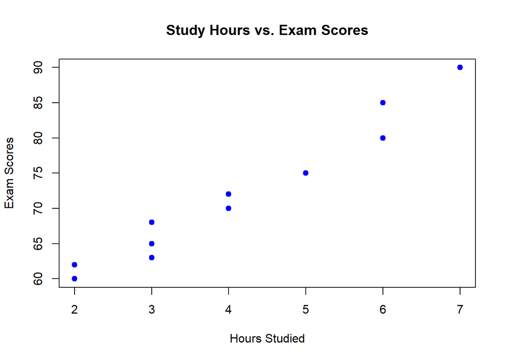

```r
# Create a scatter plot
plot(hours_studied, exam_scores,
     main = "Study Hours vs. Exam Scores",  # Title of the plot
     xlab = "Hours Studied",               # Label for the x-axis
     ylab = "Exam Scores",                # Label for the y-axis
     col = "blue",                        # Point color
     pch = 19)                            # Point shape (filled circle)
```

Here’s another example of a scatter plot using R. In this scenario, we’ll create a scatterplot to visualize the relationship between the Weight (1000 lbs) of cars (wt) and Miles/(US) gallon (mpg).

Note: Here we use the `mtcars` dataset available in R. The data was extracted from the 1974 Motor Trend US magazine, and comprises fuel consumption and 10 aspects of automobile design and performance for 32 automobiles (1973–74 models).

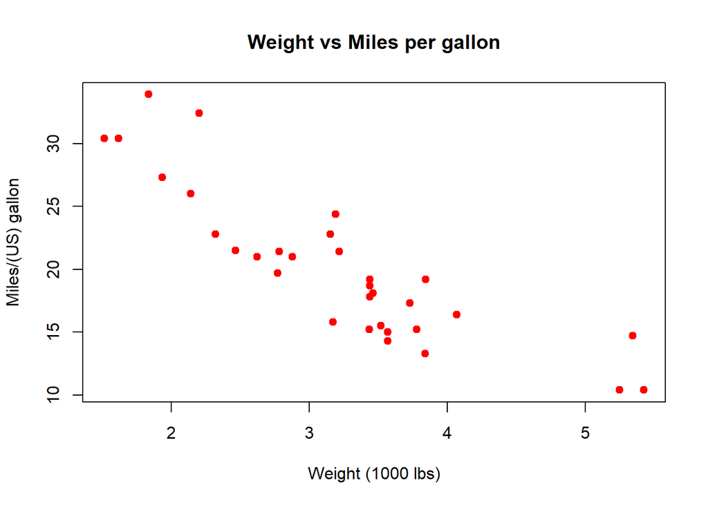

```r
x <- mtcars$wt
y <- mtcars$mpg

plot(x, y, main = "Weight vs Miles per gallon",
     xlab = "Weight (1000 lbs)", ylab = "Miles/(US) gallon",
     col = "red",
     pch = 19)
```

We can see that there is a noticeable downwards (negative) linear trend in the data. This indicates that there is, in fact, a substantial negative association between these two variables. However, there is some variability, indicating that miles per gallon cannot be perfectly predicted from the weight of the car.

### The Correlation Coefficient

So far we have been talking about linear trends in data visually, but we have not spoken about how to quantify this trend.

As you will have learned in class, the way that we quantify our linear trends is through a statistic called the correlation coefficient.

$r =\frac{\sum_{i=1}^{n} (x_i - \bar{x})(y_i - \bar{y})}{(n-1)s_Xs_Y}$

This statistic, as you know, is a measurement of the direction and strength of the linear relationship between two (quantitative) variables.

In R, we can calculate the correlation between two vectors with the function `cor`.

To use this function, we must supply it with the two vectors we wish to find the correlation of (the order does not matter).

Below we will find the correlation coefficient between the hours spent on studying and the exam scores (example 1).

```r
cor(hours_studied, exam_scores)
```

```
## [1] 0.9760194
```

We can see that the correlation coefficients is positive, confirming the positive, (or, “upward”) trend that we saw in our scatterplots.

Below we will find the correlation coefficient between the Weight (1000 lbs) of cars (wt) and Miles/(US) gallon (mpg) (example 2).

```r
cor(mtcars$wt, mtcars$mpg)
```

```
## [1] -0.8676594
```

We can see that the correlation coefficients is negative, confirming the negative, (or, “downward”) trend that we saw in our scatterplots.

#### Changing Units

One interesting feature of the correlation coefficicent is that it has no units. What this means is that, even if we change the units of our original measurement, the correlation coefficient will stay the same.

```r
# Sample data with two variables
weight_kg <- c(65, 69, 77, 80, 83, 90)  # Weight in kilograms
weight_lb <- weight_kg * 2.20462  # Convert weight to pounds
height_cm <- c(160, 165, 169, 175, 183, 185)  # Height in centimeters

# Calculate the correlation coefficient between weight (kg) and height (cm)
correlation_kg_cm <- cor(weight_kg, height_cm)

# Calculate the correlation coefficient between weight (lb) and height (cm)
correlation_lb_cm <- cor(weight_lb, height_cm)

# Print the correlation coefficients
cat("Correlation (kg vs. cm):", correlation_kg_cm, "\n")
```

```
## Correlation (kg vs. cm): 0.9667883
```

```r
cat("Correlation (lb vs. cm):", correlation_lb_cm, "\n")
```

```
## Correlation (lb vs. cm): 0.9667883
```

In this example, we have two variables: weight and height. We calculate the correlation coefficient between weight (in kilograms) and height (in centimeters) and then between weight (in pounds) and height (in centimeters). You’ll notice that the correlation coefficient remains the same (correlation is not affected by the units of measurement).

The conversion from kilograms to pounds is done using the approximate conversion factor of 1 kg = 2.20462 pounds. Despite the change in units, the correlation remains constant because it’s a unitless measure of the strength and direction of the linear relationship between the variables.

#### Using “par”

In R, we can create an image that contains multiple graphs with the use of the par function.

The par function is used to send certain parameters to the plotting window, and it can take a wide range of arguments. Today, we will only cover how to use the mfrow argument.

The mfrow argument is used to place plots side-by-side. To use the mfrow, we set it equal to a vector that contains the number of rows and columns we would like to see in our plotting window, respectively.

Consider scatterplots of example 1 (Study Hours vs. Exam Scores) and example 2 (Weight vs Miles per gallon). With `plot` function creates two separate images. However, to create a single image that displays these plots side-by-side (that is, a single row of plots with two columns), we first use the par function, as below.

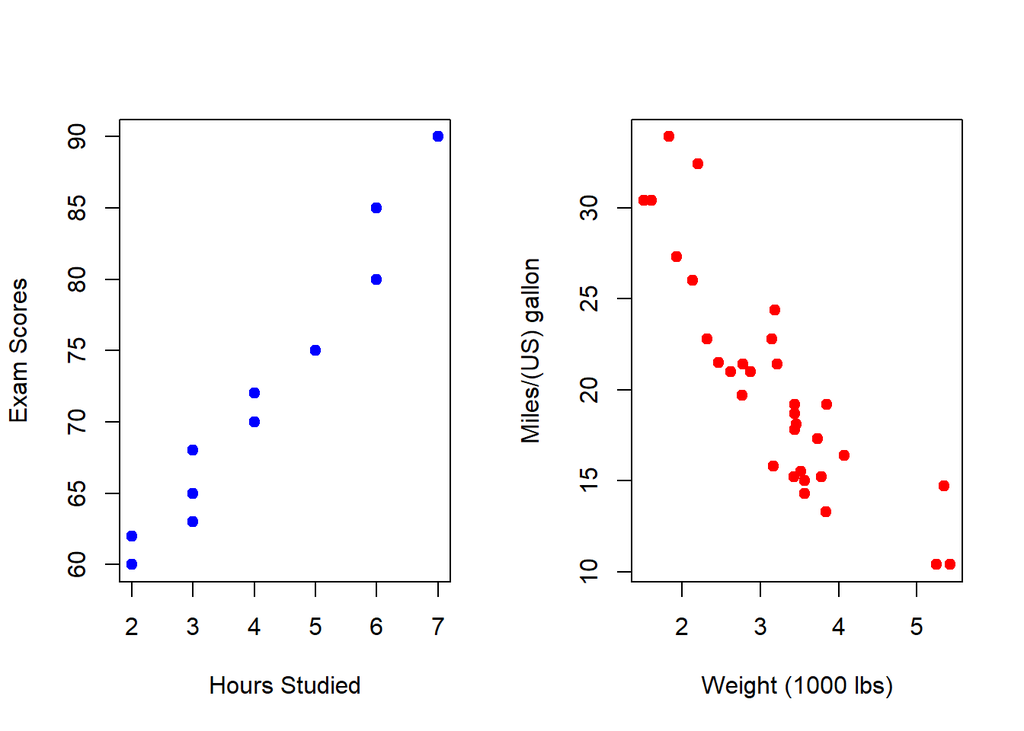

```r
par(mfrow = c(1, 2))
plot(hours_studied, exam_scores, col="blue", pch = 19,
     xlab = "Hours Studied", ylab = "Exam Scores")
plot(mtcars$wt, mtcars$mpg, col="red", pch = 19,
     xlab = "Weight (1000 lbs)", ylab = "Miles/(US) gallon")
```

As you can see, this now puts the two images side-by-side. Note that `par` will stay this way, producing plots side-by-side, until we return par to its default values by running the code below.

```r
dev.off()
```